# Краткое введение в мир линейной алгебры. Часть 2

## Применение свойства сингулярных чисел в сжатии изображений

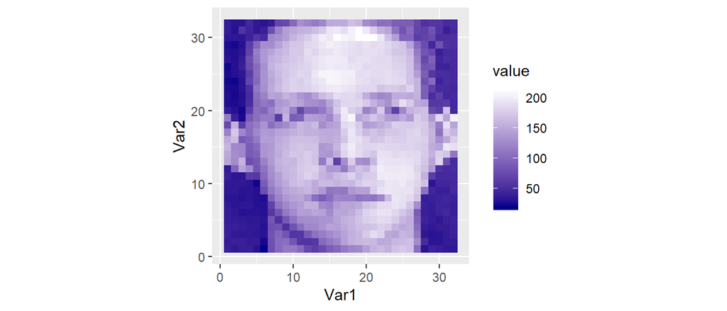

Пример взят из курса лекций “Data Analysis” by Jeffrey Leek

(https://github.com/jtleek/dataanalysis/tree/master/week3)

## Произведем сингулярное разложение матрицы `faceData`

```r
SVD_face <- svd(faceData)

U <- SVD_face$u
D <- SVD_face$d
V <- SVD_face$v
```

## Рекоструируем изображение, используя только часть информации

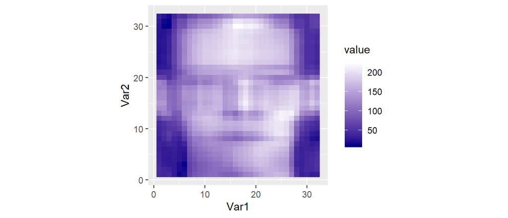

```r
reduction <- function(x) U[,1:x] %*% diag(D[1:x]) %*% t(V[, 1:x])
gg_face(reduction(4))
```

## Применение SVD в биологических исследованиях

SVD - это метод, на котором основаны разные типы анализа, связанные со снижением размерности: PCA, CA, CCA, RDA.

О них в следующех лекциях

## Summary

- Линейная алгебра позволяет решать самые разные типы задач.
- Матричные методы лежат в основе очень многих типов анализа.
- В основе многих методов снижения размерности лежит SVD.

## Что почитать

- Legendre P., Legendre L. (2012) Numerical ecology. Second english edition. Elsevier, Amsterdam. Глава 2. Matrix algebra: a summary.

## Not The End

[figure not shown]